# Glycosyltransferases in the Casei Group

Stijn Wittouck

15th of June 2017

```r
library(tidyverse)
library(stringr)
```

# 1 Data preparation

We will load the necessary (tidy) tables:

- **T_gene** (the version with gene coordinates in the genome (as opposed to in the contigs))
- **T_genome**: we need to be able to select genomes of a given clade
- **T_orthogroup**: we need to know which orthogroups are the GTs

```r
load(file = "intermediate/T_gene_withCo.Robject")
load(file = "intermediate/T_genome.Robject")
load(file = "intermediate/T_orthogroup.Robject")
```

Let’s add the genome information as well as the orthogroup information to the gene table:

```r
T_gene <- T_gene_withCo %>%
  left_join(T_genome) %>%
  left_join(T_orthogroup)
```

Now we give all genes a “position number” within their genome (not contig, because the contigs are ordered!) - this is needed for later clustering of GT genes. We then extract only the GT genes from the gene table. There are two types of GT genes:

- cazyFam families with “GT” in their names
- the extra GT families downloaded from pFam: Bac_transf, DAD and OST3_OST6

And finally, we cluster the GTs based on the number of genes in between them: if there are two or less genes between a GT and the previous GT, we consider them part of the same gene cluster.

```r
T_gts <- T_gene %>%
  arrange(genome, start_inGenome) %>%
  group_by(genome) %>%
  mutate(position_number = 1:n()) %>%
  filter(str_detect(cazyFam, "GT|Bac|OST")) %>%
  mutate(cluster_with_previous = ifelse(position_number - lag(position_number) <= 3, T, F)) %>%
  ungroup() %>%
  mutate(position_in_cluster = 1)

for (i in 1:nrow(T_gts)) {
  cluster_with_previous <- T_gts[i, "cluster_with_previous"]
  if (! is.na(cluster_with_previous) & cluster_with_previous) {
    T_gts[i, "position_in_cluster"] <- T_gts[i - 1, "position_in_cluster"] + 1
  }
}
```

# 2 Clustering analysis of GTs

Goals:

- Characterize the variation of GT-rich clusters within and between the three Casei group clades.
- Look for large GT clusters; these might be part of existing and possibly novel EPS clusters.

## 2.1 GT-rich clusters in clade A

We extract the GCA numbers of all closed genomes of clade A (L. paracasei) from a txt file. We make a gene table for these genomes only.

```r
cladeA_genomes <- read_table(file = "input/strain_selections/cladeA_completeAssemblies.txt", col_names = F) %>%
  pull(X1)

T_gts_cladeA <- T_gts %>%
  filter(genome %in% cladeA_genomes)
```

Now we can plot some stuff

[figure not shown]

```r
plot_cazyFams <- function(T_gts) {
  ggplot(T_gts, aes(x = start_inGenome, y = position_in_cluster, col = cazyFam)) +
  geom_point() +
  facet_wrap(~ strain_ordered, scales = "free_y", ncol = 1) +
  scale_color_brewer(palette = "Paired") +
  theme(axis.text.y = element_blank(),
        axis.ticks.y = element_blank(),
        panel.grid = element_blank(),
        panel.background = element_blank())
}

plot_cazyFams(T_gts_cladeA)
```

```r
ggsave("results/gts_in_genome_cladeA_closed_genomes.png", width = 30, height = 30, units = "cm")
```

## 2.2 GT-rich clusters in clade B

We will plot all genomes of clade B (L. casei), also the contig-level ones, because there are only ten in total.

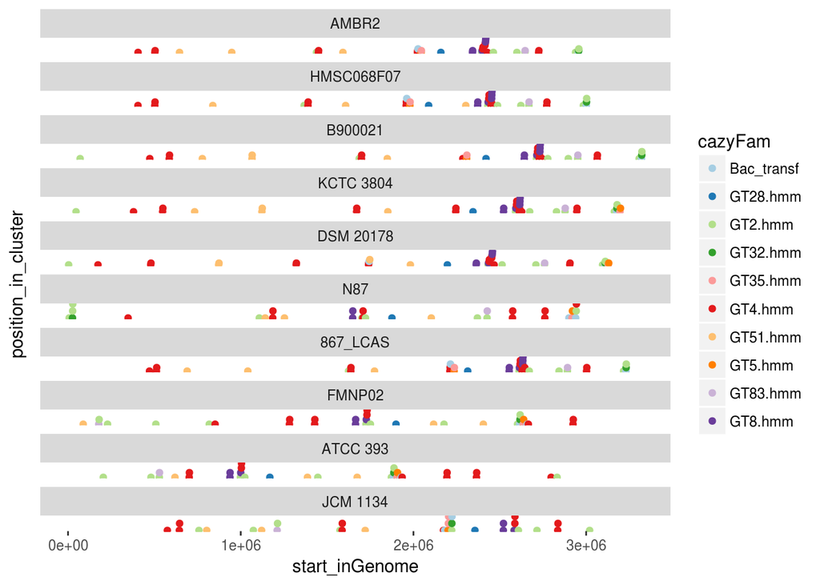

```r
T_gts_cladeB <- T_gts %>%
  filter(clade == "cladeB")
plot_cazyFams(T_gts_cladeB)
```

```r
ggsave("results/gts_in_genome_cladeB_all_genomes.png", width = 30, height = 20, units = "cm")
```

## 2.3 GT-rich clusters in clade C

We extract the GCA numbers of all closed genomes of clade C (L. rhamnosus) from a txt file. We make a gene table for these genomes only.

```r
cladeC_genomes <- read_table(file = "input/strain_selections/cladeC_completeAssemblies.txt", col_names = F) %>%
  pull(X1)

T_gts_cladeC <- T_gts %>%
  filter(genome %in% cladeC_genomes)
```

Let’s plot them:

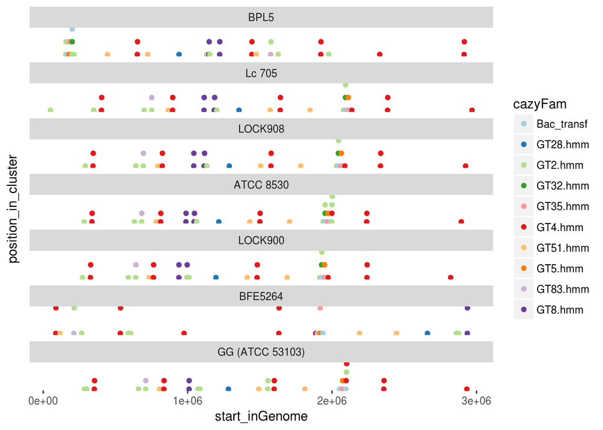

```r
plot_cazyFams(T_gts_cladeC)
```

```r
ggsave("results/gts_in_genome_cladeC_closed_genomes.png", width = 30, height = 15, units = "cm")
```

After searching manually in a genome browser for quite some time, we managed to locate the EPS cluster described by Lebeer et al. (2009) in LGG. This cluster should contain six GTs, but we could find only four of these using our approach: welE (Bac_transf; priming GT!), welF (GT4), welH (GT2) and welI (GT4). The lengths of these genes reported in the paper are approximately equal to the lengths we find here.

## 2.4 Selection of genomes across clades

To make the comparison between clades easier, we visualize the GTs in a random selection of three genomes from each clade.

```r
selection_genomes <- read_csv(file = "input/strain_selections/clades_selection.txt", col_names = F) %>%
  pull(X1)

T_gts_selection <- T_gts %>%
  filter(genome %in% selection_genomes)
```

Let’s plot them:

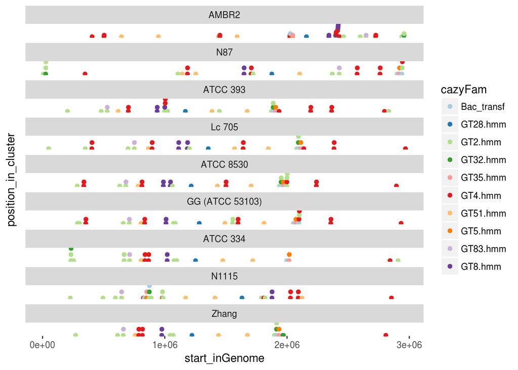

```r
plot_cazyFams(T_gts_selection)
```

```r
ggsave("results/gts_in_genome_selection.png", width = 30, height = 30, units = "cm")
```

## 2.5 Observations from these figures

Some observations: